# Reading positioning and crowding risk

**Use case: [Read positioning & risk](https://aperiodic.io/use-cases/positioning-and-risk)**

Funding, basis, and open interest each describe a different part of derivatives positioning pressure. This notebook combines them into a transparent **crowding score** built from trailing rolling percentile ranks, then examines forward returns, realised volatility, and in-window drawdowns when the leverage indicators point the same way.

We use **Binance BTC perpetuals** (`perpetual-BTC-USDT:USDT`) at **5-minute** resolution over **May 2025**, the window served by the shared `DEMO-KEY` preview slice.

> **One month is an illustration, not evidence.** Conditional returns, Sharpe-like summaries, and drawdown thresholds below come from a single month of 5-minute data. The observed thresholds will not necessarily generalise; a high score is a **risk-state diagnostic**, not a crash forecast.

**Background reading**

- Aperiodic derivatives metrics: https://aperiodic.io/metrics/derivatives
- Binance Academy, funding rates: https://www.binance.com/en/academy/articles/what-are-funding-rates-in-crypto-markets

## 1. The crowding hypothesis

Aperiodic's derivatives metrics describe positioning from three angles:

- **Funding** shows financing pressure — persistently positive funding means longs are paying to stay long.
- **Basis** shows the futures-versus-spot dislocation — a rich basis is a crowded, levered-long tell.
- **Open interest** shows how much leverage is outstanding, and whether it is building or unwinding.

The **hypothesis** is that agreement across all three — financing, dislocation, and outstanding leverage all stretched the same way — marks a crowded trade that is more vulnerable to a sharp unwind. That is a claim about **conditional tails across many regimes**, which a single month cannot confirm or refute. What this notebook *can* do honestly is build the score transparently (trailing, look-ahead-free, sign-preserving) and report what actually followed high readings in May 2025 — including when the data disagrees with the hypothesis.

```python
from __future__ import annotations

import os
from datetime import date

import matplotlib.dates as mdates
import matplotlib.pyplot as plt
import numpy as np
import pandas as pd
import seaborn as sns
from aperiodic import get_derivative_metrics, get_ohlcv

sns.set_theme(style="whitegrid", context="talk", palette="deep")
pd.options.display.float_format = "{:,.4f}".format
plt.rcParams["figure.figsize"] = (14, 6)
plt.rcParams["figure.dpi"] = 140
plt.rcParams["savefig.dpi"] = 140
plt.rcParams["axes.spines.top"] = False
plt.rcParams["axes.spines.right"] = False
```

## 2. Configuration

Uppercase constants hold the public parameters. The forward horizons are expressed in 5-minute bars; the helper below prints their human-readable durations. The API key resolves **inline value → `APERIODIC_API_KEY` → `DEMO-KEY`**.

```python
EXCHANGE = "binance-futures"
SYMBOL = "perpetual-BTC-USDT:USDT"
INTERVAL = "5m"
START_DATE = date(2025, 5, 1)
END_DATE = date(2025, 5, 31)
TIMESTAMP = "exchange"
START_TS = pd.Timestamp(START_DATE)
END_TS = pd.Timestamp(END_DATE) + pd.Timedelta(days=1)

# Trailing window (bars) for rolling percentile ranks: 7 days of 5-minute bars.
RANK_WINDOW = 7 * 24 * 12
# Forward horizons (bars) for the event study: 1 hour, 6 hours, 1 day.
FORWARD_HORIZONS = [12, 72, 288]
# Pre-declared crowding-score thresholds for the calibration table.
SCORE_THRESHOLDS = [0.6, 0.7, 0.8, 0.9]

API_KEY = "..."  # Set your key here, or via the APERIODIC_API_KEY env var
if API_KEY == "...":
    API_KEY = os.environ.get("APERIODIC_API_KEY", "DEMO-KEY")

# Only the shared "DEMO-KEY" runs against the preview endpoint. Provide your own
# key (above or via APERIODIC_API_KEY) to use the standard endpoint.
USE_PREVIEW = API_KEY == "DEMO-KEY"


def horizon_label(bars: int) -> str:
    minutes = bars * 5
    if minutes % 1440 == 0:
        return f"{minutes // 1440}d"
    if minutes % 60 == 0:
        return f"{minutes // 60}h"
    return f"{minutes}m"


print(f"Exchange / symbol : {EXCHANGE} / {SYMBOL}")
print(f"Interval / window : {INTERVAL} | {START_DATE} → {END_DATE}")
print(f"Rank window       : {RANK_WINDOW} bars ({horizon_label(RANK_WINDOW)})")
print(f"Forward horizons  : {[f'{h} bars ({horizon_label(h)})' for h in FORWARD_HORIZONS]}")
print(f"Mode              : {'preview (DEMO-KEY)' if USE_PREVIEW else 'standard endpoint'}")
```

```
Exchange / symbol : binance-futures / perpetual-BTC-USDT:USDT
Interval / window : 5m | 2025-05-01 → 2025-05-31
Rank window       : 2016 bars (7d)
Forward horizons  : ['12 bars (1h)', '72 bars (6h)', '288 bars (1d)']
Mode              : standard endpoint
```

## Helper functions

`clip_window` and `format_time_axis` match the introductory notebooks; `rolling_rank` is the trailing percentile-rank transform from `alpha-discovery.py`; `forward_return`, `forward_vol`, and `forward_max_drawdown` summarise the path over the next *h* bars using only future prices for the *outcome* (never for the score); and `audit_columns` prints the fetched schema and fails loudly if a required field is absent.

**Show helper code · 57 lines**

```python
def clip_window(df: pd.DataFrame) -> pd.DataFrame:
    out = df.copy()
    out["time"] = pd.to_datetime(out["time"])
    out = out.loc[(out["time"] >= START_TS) & (out["time"] < END_TS)]
    return out.sort_values("time").reset_index(drop=True)


def format_time_axis(ax):
    locator = mdates.AutoDateLocator(minticks=6, maxticks=10)
    formatter = mdates.ConciseDateFormatter(locator)
    ax.xaxis.set_major_locator(locator)
    ax.xaxis.set_major_formatter(formatter)


def audit_columns(frames: dict[str, tuple[pd.DataFrame, list[str]]]) -> None:
    lines, problems = [], []
    for name, (frame, required) in frames.items():
        cols = sorted(map(str, frame.columns))
        missing = [c for c in required if c not in frame.columns]
        lines.append(f"- {name:<16} {len(frame):>5} rows | columns={cols}")
        if missing:
            problems.append(f"{name} missing {missing}")
    report = "Fetched schema:\n" + "\n".join(lines)
    print(report)
    if problems:
        raise KeyError("; ".join(problems) + "\n" + report)


def rolling_rank(series: pd.Series, window: int) -> pd.Series:
    """Trailing rolling percentile rank in [0, 1] (alpha-discovery transform).
    Uses only data up to and including the current bar — no look-ahead. Requires a
    quarter-window of history so day-one "7-day" ranks are not seeded off a handful
    of observations."""
    min_periods = max(10, window // 4)
    ranks = series.rolling(window, min_periods=min_periods).rank(method="average")
    counts = series.rolling(window, min_periods=min_periods).count()
    return (ranks - 1.0) / (counts - 1.0)


def forward_return(close: pd.Series, horizon: int) -> pd.Series:
    """Return over the future window (t, t+horizon]."""
    return close.pct_change(horizon).shift(-horizon)


def forward_vol(ret: pd.Series, horizon: int) -> pd.Series:
    """Std of per-bar returns over the strictly-future bars t+1 .. t+horizon.
    `rolling(h)` at index t+h spans [t+1, t+h]; `shift(-h)` re-anchors it to t, so
    the contemporaneous bar `ret[t]` (known at score time) is excluded."""
    return ret.rolling(horizon, min_periods=max(2, horizon // 4)).std().shift(-horizon)


def forward_max_drawdown(close: pd.Series, horizon: int) -> pd.Series:
    """Most negative move from close[t] to the lowest close in t+1 .. t+horizon
    (clipped at 0). The current bar is excluded, so `.clip(upper=0)` — not a trivial
    self-observation — is what enforces the '<= 0' semantics."""
    fwd_min = close.rolling(horizon, min_periods=1).min().shift(-horizon)
    return (fwd_min / close - 1.0).clip(upper=0.0)
```

## 3. Fetch and align derivative data

Five requests share the common arguments (`api_key`, `preview`, `timestamp`, `interval`, `exchange`, `symbol`, `start_date`, `end_date`, `output="pandas"`, `show_progress=False`): price, funding, basis, open interest, and derivative price. We align on `time` without look-ahead, forward-filling sparse derivative observations only forward. Derivative price is kept as a **cross-check** on the OHLCV return source, not a replacement.

```python
COMMON = dict(
    api_key=API_KEY,
    preview=USE_PREVIEW,
    timestamp=TIMESTAMP,
    interval=INTERVAL,
    exchange=EXCHANGE,
    symbol=SYMBOL,
    start_date=START_DATE,
    end_date=END_DATE,
    output="pandas",
    show_progress=False,
)

ohlcv = clip_window(get_ohlcv(**COMMON))
funding = clip_window(get_derivative_metrics(metric="funding", **COMMON))
basis = clip_window(get_derivative_metrics(metric="basis", **COMMON))
open_interest = clip_window(get_derivative_metrics(metric="open_interest", **COMMON))
derivative_price = clip_window(get_derivative_metrics(metric="derivative_price", **COMMON))

audit_columns(
    {
        "ohlcv": (ohlcv, ["time", "close"]),
        "funding": (funding, ["time", "funding_rate"]),
        "basis": (basis, ["time", "basis_bps"]),
        "open_interest": (open_interest, ["time", "open_interest", "open_interest_pct_change"]),
        "derivative_price": (
            derivative_price,
            [
                "time",
                "last_price",
                "index_price",
                "mark_price",
                "last_price_pct_change",
                "index_price_pct_change",
                "mark_price_pct_change",
            ],
        ),
    }
)
```

```
Fetched schema:
- ohlcv             8928 rows | columns=['close', 'high', 'low', 'open', 'time', 'volume', 'volume_notional']
- funding           8928 rows | columns=['funding_rate', 'funding_rate_avg_update_interval', 'funding_rate_update_frequency', 'time']
- basis             8928 rows | columns=['basis', 'basis_bps', 'basis_bps_std', 'basis_mean', 'mark_price_spread', 'mark_price_spread_bps', 'mark_price_spread_bps_std', 'mark_price_spread_mean', 'time']
- open_interest     8928 rows | columns=['oi_price_change_ratio', 'open_interest', 'open_interest_pct_change', 'open_interest_volatility', 'time']
- derivative_price  8928 rows | columns=['index_last_pct_change_ratio', 'index_price', 'index_price_pct_change', 'last_price', 'last_price_pct_change', 'mark_index_pct_change_ratio', 'mark_last_pct_change_ratio', 'mark_price', 'mark_price_pct_change', 'time']
```

```python
df = (
    ohlcv[["time", "close"]]
    .merge(funding[["time", "funding_rate"]], on="time", how="left")
    .merge(basis[["time", "basis_bps"]], on="time", how="left")
    .merge(open_interest[["time", "open_interest", "open_interest_pct_change"]], on="time", how="left")
    .merge(
        derivative_price[["time", "mark_price", "mark_price_pct_change"]],
        on="time",
        how="left",
    )
    .sort_values("time")
    .reset_index(drop=True)
)

# Align sparse derivative series forward only (never pull later values backwards).
for col in ["funding_rate", "basis_bps", "open_interest", "open_interest_pct_change"]:
    df[col] = df[col].ffill()

df["ret"] = df["close"].pct_change()
df["funding_rate_bps"] = df["funding_rate"] * 1e4

# Cross-check: derivative mark-price return vs OHLCV close return (we keep close).
cross_check = df[["ret", "mark_price_pct_change"]].dropna()
mark_corr = cross_check["ret"].corr(cross_check["mark_price_pct_change"]) if len(cross_check) > 2 else np.nan

coverage = pd.Series(
    {
        "Rows (5m bars)": len(df),
        "Start": df["time"].min(),
        "End": df["time"].max(),
        "Mean funding (bps)": df["funding_rate_bps"].mean(),
        "Mean basis (bps)": df["basis_bps"].mean(),
        "Median open interest": df["open_interest"].median(),
        "corr(close ret, mark-price ret)": mark_corr,
    }
)
coverage
```

```
Rows (5m bars)                                    8928
Start                              2025-05-01 00:00:00
End                                2025-05-31 23:55:00
Mean funding (bps)                              0.4869
Mean basis (bps)                               -4.1689
Median open interest                       82,897.7935
corr(close ret, mark-price ret)                 0.9959
dtype: object
```

## Chart 1 — Positioning components

Funding, basis, and open interest with price context. These are the raw ingredients of the crowding score; the strongest coincident moves in May 2025 are visible, but they are features of this window, not universal regimes.

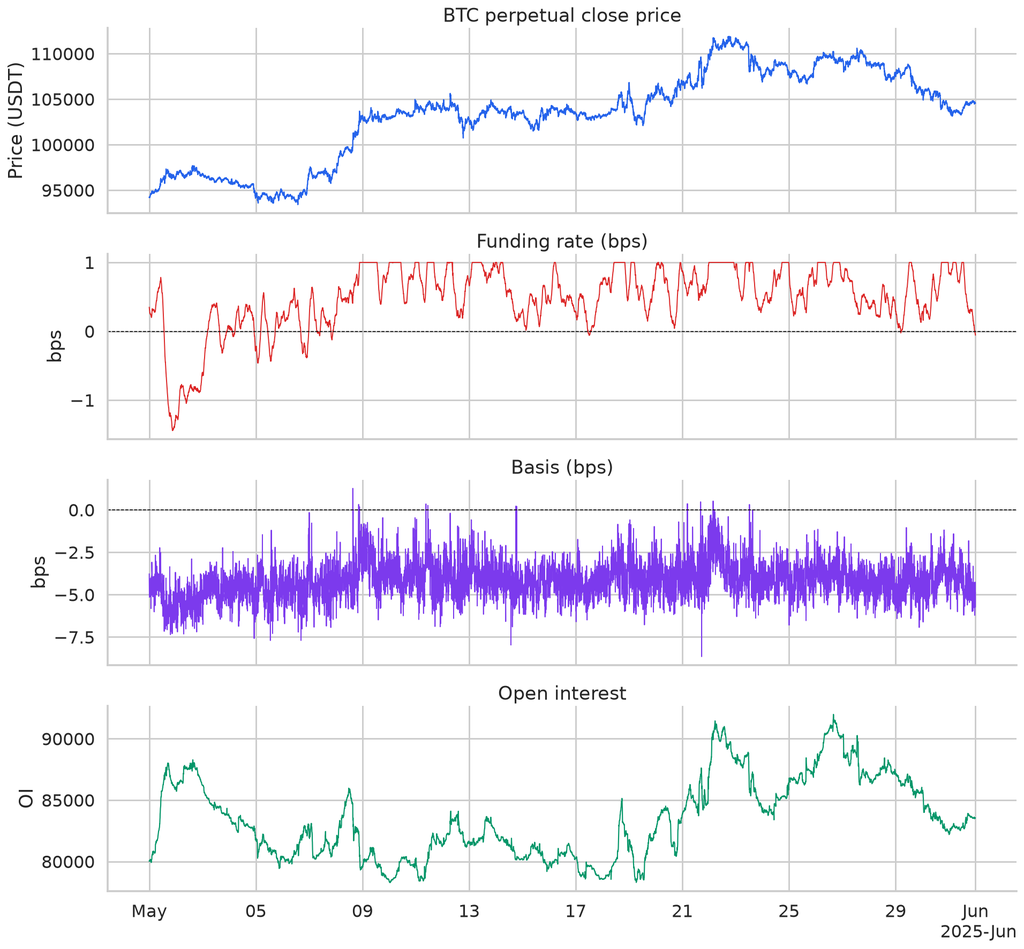

```python
fig, axes = plt.subplots(4, 1, figsize=(14, 13), sharex=True)
axes[0].plot(df["time"], df["close"], color="#2563eb", linewidth=1.2)
axes[0].set_title("BTC perpetual close price")
axes[0].set_ylabel("Price (USDT)")

axes[1].plot(df["time"], df["funding_rate_bps"], color="#dc2626", linewidth=1.0)
axes[1].axhline(0, color="black", linestyle="--", linewidth=0.8)
axes[1].set_title("Funding rate (bps)")
axes[1].set_ylabel("bps")

axes[2].plot(df["time"], df["basis_bps"], color="#7c3aed", linewidth=1.0)
axes[2].axhline(0, color="black", linestyle="--", linewidth=0.8)
axes[2].set_title("Basis (bps)")
axes[2].set_ylabel("bps")

axes[3].plot(df["time"], df["open_interest"], color="#059669", linewidth=1.1)
axes[3].set_title("Open interest")
axes[3].set_ylabel("OI")
format_time_axis(axes[3])
plt.tight_layout()
```

## 4. Build the crowding score

Each component is mapped to a trailing rolling percentile rank over `RANK_WINDOW` bars (7 days), so a value near **1** means "unusually stretched *long*" and near **0** means "unusually stretched *short*" relative to the recent past:

- `funding_rate` — higher rank = longs paying more.
- `basis_bps` — higher rank = richer futures premium.
- **1-day** open-interest change — higher rank = leverage building fastest. We rank the trailing 1-day OI change (`open_interest.pct_change(288)`), **not** the raw 5-minute change: at 5-minute frequency the OI change is ~white noise whose rank oscillates around 0.5, which would only dilute the composite. Section 1's "leverage building or unwinding" is an hours-to-days concept, so we measure it over a day.

The composite is the **simple mean** of the three ranks (a transparent, fixed-weight combination). Because ranks preserve direction, the composite sits in [0, 1] with **> 0.5 = long crowding, < 0.5 = short crowding** — the sign is kept, not collapsed to magnitude. Ranks and the composite use trailing data only.

Note that funding and basis both price the perp-vs-index premium, so they are correlated by construction; we print their rank correlations so the composite is not read as three independent inputs.

```
Rank correlation between components (funding & basis both price the premium):
|                |   rank_funding |   rank_basis |   rank_oi_change |
|:---------------|---------------:|-------------:|-----------------:|
| rank_funding   |           1    |         0.42 |             0.33 |
| rank_basis     |           0.42 |         1    |             0.12 |
| rank_oi_change |           0.33 |         0.12 |             1    |
```

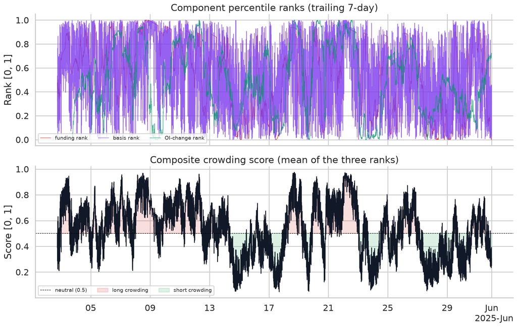

```python
df["oi_change_1d"] = df["open_interest"].pct_change(288)  # 1-day leverage build
df["rank_funding"] = rolling_rank(df["funding_rate"], RANK_WINDOW)
df["rank_basis"] = rolling_rank(df["basis_bps"], RANK_WINDOW)
df["rank_oi_change"] = rolling_rank(df["oi_change_1d"], RANK_WINDOW)
df["crowding_score"] = df[["rank_funding", "rank_basis", "rank_oi_change"]].mean(axis=1)

rank_cols = ["rank_funding", "rank_basis", "rank_oi_change"]
print("Rank correlation between components (funding & basis both price the premium):")
print(df[rank_cols].dropna().corr().round(2).to_markdown())

# Forward outcomes for the event study (future prices used only for the outcome).
for h in FORWARD_HORIZONS:
    df[f"fwd_ret_{h}"] = forward_return(df["close"], h)
    df[f"fwd_vol_{h}"] = forward_vol(df["ret"], h)
    df[f"fwd_maxdd_{h}"] = forward_max_drawdown(df["close"], h)

fig, (ax_comp, ax_score) = plt.subplots(2, 1, figsize=(14, 9), sharex=True)
ax_comp.plot(df["time"], df["rank_funding"], label="funding rank", color="#dc2626", linewidth=0.9, alpha=0.8)
ax_comp.plot(df["time"], df["rank_basis"], label="basis rank", color="#7c3aed", linewidth=0.9, alpha=0.8)
ax_comp.plot(df["time"], df["rank_oi_change"], label="OI-change rank", color="#059669", linewidth=0.9, alpha=0.8)
ax_comp.set_title("Component percentile ranks (trailing 7-day)")
ax_comp.set_ylabel("Rank [0, 1]")
ax_comp.legend(frameon=True, fontsize=10, ncol=3)

ax_score.plot(df["time"], df["crowding_score"], color="#111827", linewidth=1.3)
ax_score.axhline(0.5, color="black", linestyle="--", linewidth=0.8, label="neutral (0.5)")
ax_score.fill_between(df["time"], df["crowding_score"], 0.5, where=df["crowding_score"] > 0.5, color="#dc2626", alpha=0.15, label="long crowding")
ax_score.fill_between(df["time"], df["crowding_score"], 0.5, where=df["crowding_score"] < 0.5, color="#16a34a", alpha=0.15, label="short crowding")
ax_score.set_title("Composite crowding score (mean of the three ranks)")
ax_score.set_ylabel("Score [0, 1]")
ax_score.legend(frameon=True, fontsize=10, ncol=3)
format_time_axis(ax_score)
plt.tight_layout()
```

## Chart 2 — Event study by crowding decile

Bucket every bar by its composite-score decile and compare forward returns and realised volatility across the horizons. Sample counts are shown because the windows **overlap** — these are not independent observations, so the decile means are indicative, not statistically independent estimates.

```
Valid observations per decile at the 1d horizon:
|   score_decile |   crowding_score |
|---------------:|-----------------:|
|              1 |              842 |
|              2 |              805 |
|              3 |              799 |
|              4 |              788 |
|              5 |              810 |
|              6 |              795 |
|              7 |              811 |
|              8 |              817 |
|              9 |              827 |
|             10 |              843 |
```

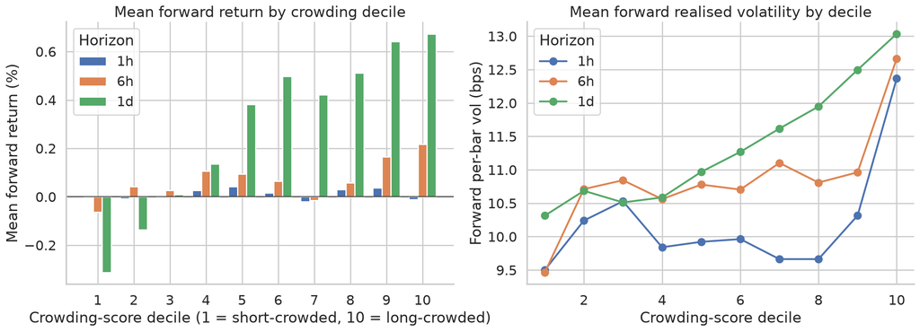

```python
event = df.dropna(subset=["crowding_score"]).copy()
# labels=False + 1 avoids a ValueError if qcut ever drops a bin (lower-variance
# symbols/windows); it yields integer deciles 1..k.
event["score_decile"] = pd.qcut(event["crowding_score"], 10, labels=False, duplicates="drop") + 1

ret_by_decile = event.groupby("score_decile", observed=True)[[f"fwd_ret_{h}" for h in FORWARD_HORIZONS]].mean() * 100
vol_by_decile = event.groupby("score_decile", observed=True)[[f"fwd_vol_{h}" for h in FORWARD_HORIZONS]].mean() * 1e4
# Count valid observations per decile at the longest horizon (tail bars have NaN
# forward outcomes and drop from the means, so this is the honest denominator).
h_long = FORWARD_HORIZONS[-1]
counts = event.dropna(subset=[f"fwd_ret_{h_long}"]).groupby("score_decile", observed=True)["crowding_score"].count()

print(f"Valid observations per decile at the {horizon_label(h_long)} horizon:")
print(counts.to_markdown())

fig, (ax_r, ax_v) = plt.subplots(1, 2, figsize=(16, 6))
width = 0.25
x = np.arange(len(ret_by_decile.index))
for i, h in enumerate(FORWARD_HORIZONS):
    ax_r.bar(x + (i - 1) * width, ret_by_decile[f"fwd_ret_{h}"], width=width, label=horizon_label(h))
ax_r.axhline(0, color="black", linewidth=0.8)
ax_r.set_title("Mean forward return by crowding decile")
ax_r.set_xlabel("Crowding-score decile (1 = short-crowded, 10 = long-crowded)")
ax_r.set_ylabel("Mean forward return (%)")
ax_r.set_xticks(x, ret_by_decile.index.astype(str))
ax_r.legend(frameon=True, title="Horizon")

for i, h in enumerate(FORWARD_HORIZONS):
    ax_v.plot(ret_by_decile.index.astype(int), vol_by_decile[f"fwd_vol_{h}"], marker="o", label=horizon_label(h))
ax_v.set_title("Mean forward realised volatility by decile")
ax_v.set_xlabel("Crowding-score decile")
ax_v.set_ylabel("Forward per-bar vol (bps)")
ax_v.legend(frameon=True, title="Horizon")
plt.tight_layout()
```

## Chart 3 — Sharpest in-window moves

The largest **distinct** adverse forward moves at the 1-day horizon, annotated with the crowding score **known immediately before** each move (a trailing input). Because overlapping 1-day windows onto a single drop would otherwise show up as several "events", we de-cluster greedily: keep the worst bar, then skip anything within one horizon of an already-selected event. The question is whether the score was already elevated ahead of these unwinds — for this window only.

[output not shown]

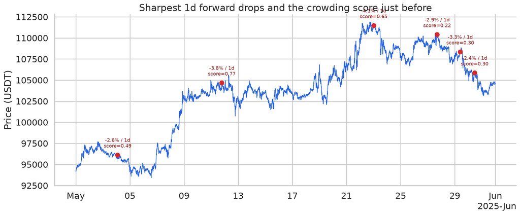

```python
h_long = FORWARD_HORIZONS[-1]
moves = df.dropna(subset=[f"fwd_ret_{h_long}", "crowding_score"]).sort_values(f"fwd_ret_{h_long}").copy()
selected: list[pd.Series] = []
for _, r in moves.iterrows():
    if all(abs((r["time"] - s["time"]).total_seconds()) > h_long * 300 for s in selected):
        selected.append(r)
    if len(selected) == 6:
        break
sharp = pd.DataFrame(selected)

fig, ax = plt.subplots(figsize=(14, 6))
ax.plot(df["time"], df["close"], color="#2563eb", linewidth=1.1)
for _, r in sharp.iterrows():
    ax.scatter(r["time"], r["close"], color="#dc2626", s=60, zorder=5)
    ax.annotate(
        f"{r['fwd_ret_' + str(h_long)] * 100:.1f}% / {horizon_label(h_long)}\nscore={r['crowding_score']:.2f}",
        (r["time"], r["close"]),
        textcoords="offset points",
        xytext=(0, 14),
        fontsize=9,
        ha="center",
        color="#991b1b",
    )
ax.set_title(f"Sharpest {horizon_label(h_long)} forward drops and the crowding score just before")
ax.set_ylabel("Price (USDT)")
format_time_axis(ax)
plt.tight_layout()

print(
    sharp[["time", "crowding_score", f"fwd_ret_{h_long}", f"fwd_maxdd_{h_long}"]]
    .assign(**{f"fwd_ret_{h_long}": lambda d: d[f"fwd_ret_{h_long}"] * 100, f"fwd_maxdd_{h_long}": lambda d: d[f"fwd_maxdd_{h_long}"] * 100})
    .to_markdown(index=False)
)
print(
    f"\nCrowding score just before these drops ranged {sharp['crowding_score'].min():.2f}–"
    f"{sharp['crowding_score'].max():.2f} (mean {sharp['crowding_score'].mean():.2f}). In this "
    "window the score was near-neutral ahead of the sharpest unwinds — i.e. it did not flag "
    "them in advance, consistent with the threshold table below."
)
```

## 5. Threshold calibration table

For a small, pre-declared set of crowding-score thresholds — **plus an unconditional baseline** (all bars) so the comparison is explicit — we report the observation count, subsequent return, realised volatility, and maximum subsequent drawdown at the 1-day horizon. This is **in-window calibration**: a description of what happened in May 2025, not a production threshold or an out-of-sample test.

```python
h = FORWARD_HORIZONS[-1]
cal = df.dropna(subset=["crowding_score", f"fwd_ret_{h}", f"fwd_vol_{h}", f"fwd_maxdd_{h}"])
rows = []
for thr in [0.0, *SCORE_THRESHOLDS]:
    sub = cal[cal["crowding_score"] >= thr]
    rows.append(
        {
            "score >= ": "all (baseline)" if thr == 0.0 else f"{thr:.1f}",
            "count": int(len(sub)),
            "share_of_sample_%": 100.0 * len(sub) / len(cal) if len(cal) else np.nan,
            f"mean_fwd_ret_{horizon_label(h)}_%": sub[f"fwd_ret_{h}"].mean() * 100,
            f"mean_fwd_vol_{horizon_label(h)}_bps": sub[f"fwd_vol_{h}"].mean() * 1e4,
            f"mean_fwd_maxdd_{horizon_label(h)}_%": sub[f"fwd_maxdd_{h}"].mean() * 100,
        }
    )
calibration_table = pd.DataFrame(rows)
print(f"In-window calibration at the {horizon_label(h)} horizon (illustrative):")
print(calibration_table.to_markdown(index=False))
```

```
In-window calibration at the 1d horizon (illustrative):
| score >=       |   count |   share_of_sample_% |   mean_fwd_ret_1d_% |   mean_fwd_vol_1d_bps |   mean_fwd_maxdd_1d_% |
|:---------------|--------:|--------------------:|--------------------:|----------------------:|----------------------:|
| all (baseline) |    8137 |           100       |            0.283103 |               11.3525 |              -1.23221 |
| 0.6            |    3360 |            41.2929  |            0.558944 |               12.2611 |              -1.21172 |
| 0.7            |    2013 |            24.7388  |            0.65413  |               12.6635 |              -1.18904 |
| 0.8            |     950 |            11.6751  |            0.647598 |               12.9858 |              -1.20449 |
| 0.9            |     288 |             3.53939 |            0.671128 |               12.8181 |              -1.1064  |
```

**What the table says — read straight.** In May 2025, elevated crowding preceded **above-baseline** forward returns and **unexceptional** drawdowns; only forward volatility ticks up modestly with the score. In other words, this month the score behaved as a momentum/carry-**confirmation** signal, not a fragility warning — crowding often resolved by grinding higher. That is the opposite of a "crowded leverage unwinds" story, and one month cannot establish the conditional-tail behaviour that story is about. Reporting it straight is the point: a construction that is transparent and look-ahead-free is worth showing even when the window's realised outcome does not cooperate.

## Further reading

- [Read positioning & risk](https://aperiodic.io/use-cases/positioning-and-risk)
- [Derivatives metrics](https://aperiodic.io/metrics/derivatives)
- Related notebooks: `notebooks/intro-derivatives.py`, `notebooks/alpha-discovery.py`